# Assessment Performance and Data Quality: Evidence from Philadelphia Property Sales

Nathan McClay

2026-02-23

# 1. Executive Summary

> - **Evaluated:** Alignment between OPA assessed values and observed residential sale prices in Philadelphia.
> - **Method:** Constructed an arm’s-length residential sample; assessed fit in log–log space; measured dispersion via COD; stratified by price decile and transaction-level data-quality flags.
> - **Found:** Dispersion is low and stable when transactions have **0 flags**, and rises sharply with **1+ flags**; conditional-on-price dispersion remains higher for flagged records.
> - **Why it matters:** Apparent “assessment error” is partly **data-quality-conditioned**, so uncertainty is structured—not uniform—implying targeted data integrity improvements can materially improve assessment performance.

# 2. Data and Sample Construction

## 2.1 Data Integration

> The analysis combines two public administrative datasets: - Office of Property Assessment (OPA) property characteristics file (583,776 records) - Real Estate Transfer (RTT) transaction records (218,322 documents) Records were merged at the parcel level using a standardized 9-digit parcel identifier.

```
## # A tibble: 1 × 2
##   Stage      Observations
##   <chr>             <int>
## 1 Post-Merge       202277
```

> The merged dataset links administrative assessments to observed transaction prices at the parcel level and forms the basis of the analytic sample.

## 2.2 Construction of Arm’s-Length Residential Sample

> To construct an analytic sample consistent with ratio-study standards, transactions were filtered to isolate arm’s-length residential sales. The following restrictions were applied: - Limited to recorded **DEED** transactions  
> - Excluded sheriff’s deeds and non-market transfers  
> - Removed nominal transfers below **$1,000**  
> - Restricted to residential properties  
> - Retained only single-property transfers  
> These steps align with International Association of Assessing Officers (IAAO) guidance for constructing defensible assessment ratio samples.

```
## # A tibble: 1 × 2
##   Stage                                 Observations
##   <chr>                                        <int>
## 1 Residential Arm's-Length Transactions       113534
```

> These restrictions remove non-market transfers and isolate residential deed transactions suitable for assessment ratio analysis.

## 2.3 Deduplication of Parcel-Date Transactions

> Inspection revealed multiple observations sharing identical parcel identifiers and sale dates. Investigation showed that these cases reflected multiple recorded documents tied to a single transaction rather than merge artifacts. To approximate the finalized transaction, the document with the highest total consideration was retained within each parcel–sale-date group. This approach preserves one arm’s-length observation per economic transaction while minimizing structural duplication.

```
## # A tibble: 1 × 2
##   Stage                     Observations
##   <chr>                            <int>
## 1 Post-Deduplication Sample        94494
```

> Retaining the highest total consideration within each parcel-date group ensures that each transaction enters the analysis once.

## 3. Log–Log Assessment Alignment

> As a first-order diagnostic, log-transformed assessed values are compared to log-transformed sale prices to evaluate proportional alignment across the valuation distribution.

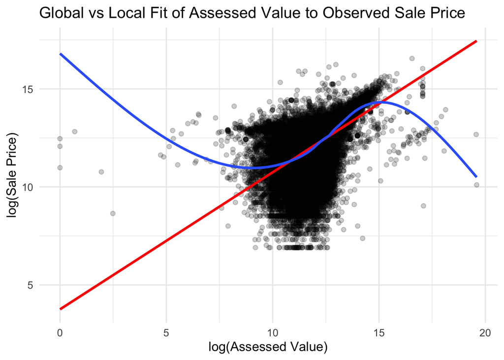

> The local smooth departs from the global log–log line at the tails, indicating that proportional alignment varies across the value distribution. This pattern is **descriptive** and may reflect a mix of market segmentation, nonlinear attribute pricing, or data-quality irregularities. For that reason, the subsequent analysis focuses on **dispersion measures** and explicitly tests whether dispersion increases with observable data-quality flags *within* valuation regimes.

## 4. Data Quality Flags and Ratio Construction

Distribution of transaction-level data-quality flags

| n_flags | n |
| --- | --- |
| 0 | 51396 |
| 1 | 27875 |
| 2 | 3629 |
| 3 | 2396 |
| 4 | 523 |
| 5 | 338 |
| 6 | 5 |

## 5. Dispersion by Flag Severity

### 5.1 Distribution of Log Assessment Ratios

> To evaluate whether dispersion is associated with flagged irregularities, log assessment ratios are stratified by the number of data-quality flags.

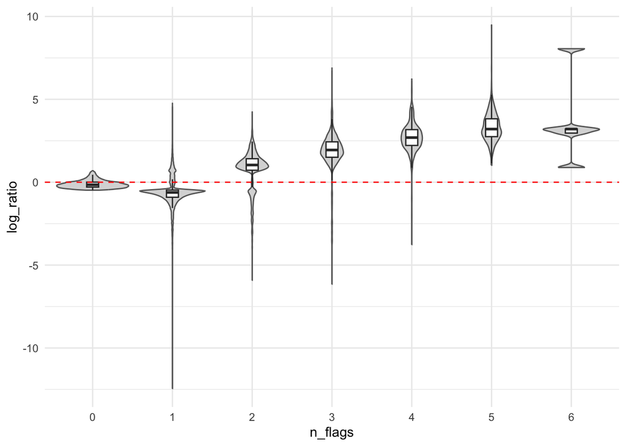

> The spread of log assessment ratios widens as the number of flags increases, indicating greater dispersion among flagged transactions.

### 5.2 Summary Dispersion Statistics

> Dispersion is quantified using the coefficient of dispersion (COD) and the interquartile range (IQR) of assessment ratios.

Assessment ratio behavior by number of data-quality flags

| n_flags | n | median_ratio | COD | IQR |
| --- | --- | --- | --- | --- |
| 0 | 51396 | 0.857 | 0.199 | 0.297 |
| 1 | 27875 | 0.539 | 0.802 | 0.434 |
| 2 | 3629 | 2.830 | 0.682 | 0.693 |
| 3 | 2396 | 6.982 | 0.982 | 0.932 |
| 4 | 523 | 14.780 | 0.920 | 0.953 |
| 5 | 338 | 24.653 | 2.623 | 1.076 |
| 6 | 5 | 24.700 | 25.501 | 0.244 |

## 6. Conditional Dispersion by Valuation Regime

### 6.1 Conditioning on Sale-Price Decile

> Because dispersion may vary across valuation regimes, transactions are stratified by sale-price decile, and COD is computed within each decile.

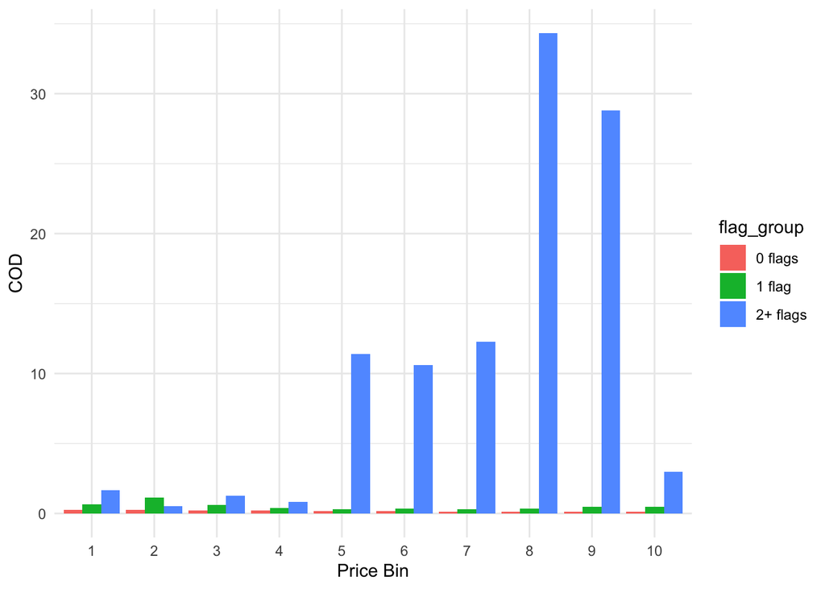

> Within most price bins, transactions with additional flags exhibit higher COD values than zero-flag transactions.

## 7. Bootstrap Validation of Dispersion Estimates

### 7.1 Sampling Variability of COD

> Bootstrap resampling is used to assess the sampling variability of COD estimates within each price-bin and flag-group cell.

[figure not shown]

Bootstrap confidence intervals for COD (cells with n ≥ 30)

| price_bin | flag_group | n | COD | COD_se | COD_ci_lo | COD_ci_hi |
| --- | --- | --- | --- | --- | --- | --- |
| 1 | 0 flags | 2202 | 0.239 | 0.004 | 0.231 | 0.246 |
| 1 | 1 flag | 2150 | 0.637 | 0.029 | 0.585 | 0.698 |
| 1 | 2+ flags | 4265 | 1.659 | 0.434 | 1.095 | 2.703 |
| 2 | 0 flags | 5054 | 0.244 | 0.003 | 0.239 | 0.250 |
| 2 | 1 flag | 2183 | 1.124 | 0.028 | 1.072 | 1.181 |
| 2 | 2+ flags | 1380 | 0.500 | 0.084 | 0.364 | 0.688 |
| 3 | 0 flags | 5112 | 0.235 | 0.003 | 0.229 | 0.240 |
| 3 | 1 flag | 3160 | 0.602 | 0.018 | 0.567 | 0.638 |
| 3 | 2+ flags | 344 | 1.263 | 0.595 | 0.457 | 2.572 |
| 4 | 0 flags | 5148 | 0.198 | 0.002 | 0.193 | 0.203 |
| 4 | 1 flag | 3338 | 0.403 | 0.013 | 0.378 | 0.428 |
| 4 | 2+ flags | 130 | 0.807 | 0.230 | 0.454 | 1.336 |
| 5 | 0 flags | 5077 | 0.176 | 0.002 | 0.171 | 0.180 |
| 5 | 1 flag | 3482 | 0.317 | 0.011 | 0.297 | 0.339 |
| 5 | 2+ flags | 57 | 11.401 | 4.333 | 3.543 | 19.930 |
| 6 | 0 flags | 5441 | 0.152 | 0.002 | 0.149 | 0.156 |
| 6 | 1 flag | 3115 | 0.333 | 0.014 | 0.307 | 0.361 |
| 6 | 2+ flags | 60 | 10.616 | 4.477 | 3.215 | 19.875 |
| 7 | 0 flags | 5904 | 0.143 | 0.002 | 0.140 | 0.146 |
| 7 | 1 flag | 2649 | 0.316 | 0.013 | 0.292 | 0.343 |
| 7 | 2+ flags | 63 | 12.270 | 4.053 | 4.785 | 20.589 |
| 8 | 0 flags | 6044 | 0.146 | 0.002 | 0.143 | 0.149 |
| 8 | 1 flag | 2507 | 0.331 | 0.016 | 0.300 | 0.364 |
| 8 | 2+ flags | 65 | 34.338 | 21.131 | 4.948 | 82.627 |
| 9 | 0 flags | 5926 | 0.142 | 0.002 | 0.139 | 0.145 |
| 9 | 1 flag | 2585 | 0.492 | 0.019 | 0.458 | 0.532 |
| 9 | 2+ flags | 105 | 28.791 | 10.032 | 12.265 | 49.756 |
| 10 | 0 flags | 5488 | 0.133 | 0.002 | 0.130 | 0.136 |
| 10 | 1 flag | 2706 | 0.493 | 0.013 | 0.468 | 0.518 |
| 10 | 2+ flags | 422 | 2.988 | 0.759 | 1.866 | 4.857 |

> Cells with fewer than 30 observations are omitted due to unstable bootstrap inference.

## 8. Summary of Empirical Results

> The analysis proceeds from global alignment diagnostics to ratio-based dispersion measures and conditional stratification. Across specifications, dispersion increases with the accumulation of transaction-level data-quality flags. This pattern persists within valuation regimes and remains robust under bootstrap validation.